# Chapter 4 excercises

Hugo Åkerstrand

2023-09-06

### 4.2.5

```r
flights |>
  filter(arr_delay > 120) #Filter out flights that arrive more than two hours delayed
```

```
## # A tibble: 10,034 × 19
##     year month   day dep_time sched_dep_time dep_delay arr_time sched_arr_time
##    <int> <int> <int>    <int>          <int>     <dbl>    <int>          <int>
##  1  2013     1     1      811            630       101     1047            830
##  2  2013     1     1      848           1835       853     1001           1950
##  3  2013     1     1      957            733       144     1056            853
##  4  2013     1     1     1114            900       134     1447           1222
##  5  2013     1     1     1505           1310       115     1638           1431
##  6  2013     1     1     1525           1340       105     1831           1626
##  7  2013     1     1     1549           1445        64     1912           1656
##  8  2013     1     1     1558           1359       119     1718           1515
##  9  2013     1     1     1732           1630        62     2028           1825
## 10  2013     1     1     1803           1620       103     2008           1750
## # ℹ 10,024 more rows
## # ℹ 11 more variables: arr_delay <dbl>, carrier <chr>, flight <int>,
## #   tailnum <chr>, origin <chr>, dest <chr>, air_time <dbl>, distance <dbl>,
## #   hour <dbl>, minute <dbl>, time_hour <dttm>
```

```r
flights |>
  filter(dest %in% c("IAH", "HOU"))  #Filter out flights with destination Huoston
```

```
## # A tibble: 9,313 × 19
##     year month   day dep_time sched_dep_time dep_delay arr_time sched_arr_time
##    <int> <int> <int>    <int>          <int>     <dbl>    <int>          <int>
##  1  2013     1     1      517            515         2      830            819
##  2  2013     1     1      533            529         4      850            830
##  3  2013     1     1      623            627        -4      933            932
##  4  2013     1     1      728            732        -4     1041           1038
##  5  2013     1     1      739            739         0     1104           1038
##  6  2013     1     1      908            908         0     1228           1219
##  7  2013     1     1     1028           1026         2     1350           1339
##  8  2013     1     1     1044           1045        -1     1352           1351
##  9  2013     1     1     1114            900       134     1447           1222
## 10  2013     1     1     1205           1200         5     1503           1505
## # ℹ 9,303 more rows
## # ℹ 11 more variables: arr_delay <dbl>, carrier <chr>, flight <int>,
## #   tailnum <chr>, origin <chr>, dest <chr>, air_time <dbl>, distance <dbl>,
## #   hour <dbl>, minute <dbl>, time_hour <dttm>
```

```r
#Create a vector to filter flights by American, United, Delta
carrier_codes <- airlines |> filter(grepl("American|United|Delta",airlines$name)) |>
  select(carrier) |>
  unlist(use.names = F)

flights |>
  filter(carrier %in% carrier_codes) #Filter out flights by vector
```

```
## # A tibble: 139,504 × 19
##     year month   day dep_time sched_dep_time dep_delay arr_time sched_arr_time
##    <int> <int> <int>    <int>          <int>     <dbl>    <int>          <int>
##  1  2013     1     1      517            515         2      830            819
##  2  2013     1     1      533            529         4      850            830
##  3  2013     1     1      542            540         2      923            850
##  4  2013     1     1      554            600        -6      812            837
##  5  2013     1     1      554            558        -4      740            728
##  6  2013     1     1      558            600        -2      753            745
##  7  2013     1     1      558            600        -2      924            917
##  8  2013     1     1      558            600        -2      923            937
##  9  2013     1     1      559            600        -1      941            910
## 10  2013     1     1      559            600        -1      854            902
## # ℹ 139,494 more rows
## # ℹ 11 more variables: arr_delay <dbl>, carrier <chr>, flight <int>,
## #   tailnum <chr>, origin <chr>, dest <chr>, air_time <dbl>, distance <dbl>,
## #   hour <dbl>, minute <dbl>, time_hour <dttm>
```

```r
flights |>
  filter(month %in% c(7, 8, 9)) #Filter out flights that happened in July, August, & September
```

```
## # A tibble: 86,326 × 19
##     year month   day dep_time sched_dep_time dep_delay arr_time sched_arr_time
##    <int> <int> <int>    <int>          <int>     <dbl>    <int>          <int>
##  1  2013     7     1        1           2029       212      236           2359
##  2  2013     7     1        2           2359         3      344            344
##  3  2013     7     1       29           2245       104      151              1
##  4  2013     7     1       43           2130       193      322             14
##  5  2013     7     1       44           2150       174      300            100
##  6  2013     7     1       46           2051       235      304           2358
##  7  2013     7     1       48           2001       287      308           2305
##  8  2013     7     1       58           2155       183      335             43
##  9  2013     7     1      100           2146       194      327             30
## 10  2013     7     1      100           2245       135      337            135
## # ℹ 86,316 more rows
## # ℹ 11 more variables: arr_delay <dbl>, carrier <chr>, flight <int>,
## #   tailnum <chr>, origin <chr>, dest <chr>, air_time <dbl>, distance <dbl>,
## #   hour <dbl>, minute <dbl>, time_hour <dttm>
```

```r
flights |>
  filter(dep_delay == 0 & arr_delay > 120) #Filter out flights that departed on time, but arrived more than two hours delayed
```

```
## # A tibble: 3 × 19
##    year month   day dep_time sched_dep_time dep_delay arr_time sched_arr_time
##   <int> <int> <int>    <int>          <int>     <dbl>    <int>          <int>
## 1  2013    10     7     1350           1350         0     1736           1526
## 2  2013     5    23     1810           1810         0     2208           2000
## 3  2013     7     1      905            905         0     1443           1223
## # ℹ 11 more variables: arr_delay <dbl>, carrier <chr>, flight <int>,
## #   tailnum <chr>, origin <chr>, dest <chr>, air_time <dbl>, distance <dbl>,
## #   hour <dbl>, minute <dbl>, time_hour <dttm>
```

```r
flights |>
  filter(arr_delay >= 60 & (sched_arr_time - sched_dep_time) -  (arr_time - dep_time) > 30) #Filter out flights that were delayed by at least an hour, but made up over 30 minutes in flight
```

```
## # A tibble: 8,000 × 19
##     year month   day dep_time sched_dep_time dep_delay arr_time sched_arr_time
##    <int> <int> <int>    <int>          <int>     <dbl>    <int>          <int>
##  1  2013     1     1     1120            944        96     1331           1213
##  2  2013     1     1     1627           1459        88     1925           1805
##  3  2013     1     1     1716           1545        91     2140           2039
##  4  2013     1     1     1930           1745       105     2233           2112
##  5  2013     1     1     2205           1720       285       46           2040
##  6  2013     1     1     2312           2000       192       21           2110
##  7  2013     1     1     2323           2200        83       22           2313
##  8  2013     1     1     2326           2130       116      131             18
##  9  2013     1     1     2343           1724       379      314           1938
## 10  2013     1     2     1228           1045       103     1354           1212
## # ℹ 7,990 more rows
## # ℹ 11 more variables: arr_delay <dbl>, carrier <chr>, flight <int>,
## #   tailnum <chr>, origin <chr>, dest <chr>, air_time <dbl>, distance <dbl>,
## #   hour <dbl>, minute <dbl>, time_hour <dttm>
```

```r
flights |>
  arrange(desc(dep_delay), dep_time)
```

```
## # A tibble: 336,776 × 19
##     year month   day dep_time sched_dep_time dep_delay arr_time sched_arr_time
##    <int> <int> <int>    <int>          <int>     <dbl>    <int>          <int>
##  1  2013     1     9      641            900      1301     1242           1530
##  2  2013     6    15     1432           1935      1137     1607           2120
##  3  2013     1    10     1121           1635      1126     1239           1810
##  4  2013     9    20     1139           1845      1014     1457           2210
##  5  2013     7    22      845           1600      1005     1044           1815
##  6  2013     4    10     1100           1900       960     1342           2211
##  7  2013     3    17     2321            810       911      135           1020
##  8  2013     6    27      959           1900       899     1236           2226
##  9  2013     7    22     2257            759       898      121           1026
## 10  2013    12     5      756           1700       896     1058           2020
## # ℹ 336,766 more rows
## # ℹ 11 more variables: arr_delay <dbl>, carrier <chr>, flight <int>,
## #   tailnum <chr>, origin <chr>, dest <chr>, air_time <dbl>, distance <dbl>,
## #   hour <dbl>, minute <dbl>, time_hour <dttm>
```

```r
flights |>
  arrange(desc(distance/air_time)) #Sorted on fastest flight
```

```
## # A tibble: 336,776 × 19
##     year month   day dep_time sched_dep_time dep_delay arr_time sched_arr_time
##    <int> <int> <int>    <int>          <int>     <dbl>    <int>          <int>
##  1  2013     5    25     1709           1700         9     1923           1937
##  2  2013     7     2     1558           1513        45     1745           1719
##  3  2013     5    13     2040           2025        15     2225           2226
##  4  2013     3    23     1914           1910         4     2045           2043
##  5  2013     1    12     1559           1600        -1     1849           1917
##  6  2013    11    17      650            655        -5     1059           1150
##  7  2013     2    21     2355           2358        -3      412            438
##  8  2013    11    17      759            800        -1     1212           1255
##  9  2013    11    16     2003           1925        38       17             36
## 10  2013    11    16     2349           2359       -10      402            440
## # ℹ 336,766 more rows
## # ℹ 11 more variables: arr_delay <dbl>, carrier <chr>, flight <int>,
## #   tailnum <chr>, origin <chr>, dest <chr>, air_time <dbl>, distance <dbl>,
## #   hour <dbl>, minute <dbl>, time_hour <dttm>
```

```r
flights |>
  distinct(day,month,year) |> #Filter out each unique date entry to count the number of unique days with flight data
  count()
```

```
## # A tibble: 1 × 1
##       n
##   <int>
## 1   365
```

```r
flights |>
  arrange(distance) |> #Top entry is shortest trip
  arrange(desc(distance)) #Top entry is longest trip
```

```
## # A tibble: 336,776 × 19
##     year month   day dep_time sched_dep_time dep_delay arr_time sched_arr_time
##    <int> <int> <int>    <int>          <int>     <dbl>    <int>          <int>
##  1  2013     1     1      857            900        -3     1516           1530
##  2  2013     1     2      909            900         9     1525           1530
##  3  2013     1     3      914            900        14     1504           1530
##  4  2013     1     4      900            900         0     1516           1530
##  5  2013     1     5      858            900        -2     1519           1530
##  6  2013     1     6     1019            900        79     1558           1530
##  7  2013     1     7     1042            900       102     1620           1530
##  8  2013     1     8      901            900         1     1504           1530
##  9  2013     1     9      641            900      1301     1242           1530
## 10  2013     1    10      859            900        -1     1449           1530
## # ℹ 336,766 more rows
## # ℹ 11 more variables: arr_delay <dbl>, carrier <chr>, flight <int>,
## #   tailnum <chr>, origin <chr>, dest <chr>, air_time <dbl>, distance <dbl>,
## #   hour <dbl>, minute <dbl>, time_hour <dttm>
```

Filtering before arranging results in the minimal computation.

### 4.3.5

The `dep_time` is largely linear with `sched_dep_time`, the `dep_delay` is their delta

```r
dep_data <- flights |>
  select(dep_time, sched_dep_time, dep_delay)

dep_data
```

```
## # A tibble: 336,776 × 3
##    dep_time sched_dep_time dep_delay
##       <int>          <int>     <dbl>
##  1      517            515         2
##  2      533            529         4
##  3      542            540         2
##  4      544            545        -1
##  5      554            600        -6
##  6      554            558        -4
##  7      555            600        -5
##  8      557            600        -3
##  9      557            600        -3
## 10      558            600        -2
## # ℹ 336,766 more rows
```

```r
flights |> glimpse()
```

```
## Rows: 336,776
## Columns: 19
## $ year           <int> 2013, 2013, 2013, 2013, 2013, 2013, 2013, 2013, 2013, 2…
## $ month          <int> 1, 1, 1, 1, 1, 1, 1, 1, 1, 1, 1, 1, 1, 1, 1, 1, 1, 1, 1…
## $ day            <int> 1, 1, 1, 1, 1, 1, 1, 1, 1, 1, 1, 1, 1, 1, 1, 1, 1, 1, 1…
## $ dep_time       <int> 517, 533, 542, 544, 554, 554, 555, 557, 557, 558, 558, …
## $ sched_dep_time <int> 515, 529, 540, 545, 600, 558, 600, 600, 600, 600, 600, …
## $ dep_delay      <dbl> 2, 4, 2, -1, -6, -4, -5, -3, -3, -2, -2, -2, -2, -2, -1…
## $ arr_time       <int> 830, 850, 923, 1004, 812, 740, 913, 709, 838, 753, 849,…
## $ sched_arr_time <int> 819, 830, 850, 1022, 837, 728, 854, 723, 846, 745, 851,…
## $ arr_delay      <dbl> 11, 20, 33, -18, -25, 12, 19, -14, -8, 8, -2, -3, 7, -1…
## $ carrier        <chr> "UA", "UA", "AA", "B6", "DL", "UA", "B6", "EV", "B6", "…
## $ flight         <int> 1545, 1714, 1141, 725, 461, 1696, 507, 5708, 79, 301, 4…
## $ tailnum        <chr> "N14228", "N24211", "N619AA", "N804JB", "N668DN", "N394…
## $ origin         <chr> "EWR", "LGA", "JFK", "JFK", "LGA", "EWR", "EWR", "LGA",…
## $ dest           <chr> "IAH", "IAH", "MIA", "BQN", "ATL", "ORD", "FLL", "IAD",…
## $ air_time       <dbl> 227, 227, 160, 183, 116, 150, 158, 53, 140, 138, 149, 1…
## $ distance       <dbl> 1400, 1416, 1089, 1576, 762, 719, 1065, 229, 944, 733, …
## $ hour           <dbl> 5, 5, 5, 5, 6, 5, 6, 6, 6, 6, 6, 6, 6, 6, 6, 5, 6, 6, 6…
## $ minute         <dbl> 15, 29, 40, 45, 0, 58, 0, 0, 0, 0, 0, 0, 0, 0, 0, 59, 0…
## $ time_hour      <dttm> 2013-01-01 05:00:00, 2013-01-01 05:00:00, 2013-01-01 0…
```

`dep_time` is the 4th column (type = int), `dep_delay` is the 6th (type = dbl), `arr_time` is the 7th (type = int), and `arr_delay` is the 9th (type = dbl).

- Most straight forward is to pass the column names or positions, although I personally prefer names over numbers (for clarity).
- Second most straight forward (and less verbose), would be to use the `starts_with()` selector.
- More labourously, one could use both positive and negative selection; first by `select(contains(c("arr_","dep_")))` and then remove the columns starting with `sched`.
- More complicated options and combinations are of course available, but this is too complicated to be recommended.

```r
flights |>
  select(dep_time, dep_delay, arr_time, arr_delay)
```

```
## # A tibble: 336,776 × 4
##    dep_time dep_delay arr_time arr_delay
##       <int>     <dbl>    <int>     <dbl>
##  1      517         2      830        11
##  2      533         4      850        20
##  3      542         2      923        33
##  4      544        -1     1004       -18
##  5      554        -6      812       -25
##  6      554        -4      740        12
##  7      555        -5      913        19
##  8      557        -3      709       -14
##  9      557        -3      838        -8
## 10      558        -2      753         8
## # ℹ 336,766 more rows
```

```r
flights |>
  select(4, 6, 7, 9)
```

```
## # A tibble: 336,776 × 4
##    dep_time dep_delay arr_time arr_delay
##       <int>     <dbl>    <int>     <dbl>
##  1      517         2      830        11
##  2      533         4      850        20
##  3      542         2      923        33
##  4      544        -1     1004       -18
##  5      554        -6      812       -25
##  6      554        -4      740        12
##  7      555        -5      913        19
##  8      557        -3      709       -14
##  9      557        -3      838        -8
## 10      558        -2      753         8
## # ℹ 336,766 more rows
```

```r
flights |>
  select(starts_with(c("arr_", "dep_")))
```

```
## # A tibble: 336,776 × 4
##    arr_time arr_delay dep_time dep_delay
##       <int>     <dbl>    <int>     <dbl>
##  1      830        11      517         2
##  2      850        20      533         4
##  3      923        33      542         2
##  4     1004       -18      544        -1
##  5      812       -25      554        -6
##  6      740        12      554        -4
##  7      913        19      555        -5
##  8      709       -14      557        -3
##  9      838        -8      557        -3
## 10      753         8      558        -2
## # ℹ 336,766 more rows
```

```r
flights |>
 select(
   contains(
     c("arr_","dep_")) #Include the underscore, or else arr will match to carrier as well
   ) |>
  select(
    !contains("sched")
  )
```

```
## # A tibble: 336,776 × 4
##    arr_time arr_delay dep_time dep_delay
##       <int>     <dbl>    <int>     <dbl>
##  1      830        11      517         2
##  2      850        20      533         4
##  3      923        33      542         2
##  4     1004       -18      544        -1
##  5      812       -25      554        -6
##  6      740        12      554        -4
##  7      913        19      555        -5
##  8      709       -14      557        -3
##  9      838        -8      557        -3
## 10      753         8      558        -2
## # ℹ 336,766 more rows
```

It produces the same result as if `carrier` was only mentioned once.

```r
flights |>
  select(carrier, carrier)
```

```
## # A tibble: 336,776 × 1
##    carrier
##    <chr>
##  1 UA
##  2 UA
##  3 AA
##  4 B6
##  5 DL
##  6 UA
##  7 B6
##  8 EV
##  9 B6
## 10 AA
## # ℹ 336,766 more rows
```

`any_of()` is a selection helper for a character vector. As opposed to `all_of()`, this selector is not strict - meaning that it doesn’t check to make sure that all of the vector elements are found.

```r
variables <- c("year", "month", "day", "dep_delay", "arr_delay")

flights |> select(any_of(variables))
```

```
## # A tibble: 336,776 × 5
##     year month   day dep_delay arr_delay
##    <int> <int> <int>     <dbl>     <dbl>
##  1  2013     1     1         2        11
##  2  2013     1     1         4        20
##  3  2013     1     1         2        33
##  4  2013     1     1        -1       -18
##  5  2013     1     1        -6       -25
##  6  2013     1     1        -4        12
##  7  2013     1     1        -5        19
##  8  2013     1     1        -3       -14
##  9  2013     1     1        -3        -8
## 10  2013     1     1        -2         8
## # ℹ 336,766 more rows
```

It doesn’t surprise me as, select helpers have default setting `.ignore.case = TRUE`.

```r
flights |> select(contains("TIME"))
```

```
## # A tibble: 336,776 × 6
##    dep_time sched_dep_time arr_time sched_arr_time air_time time_hour
##       <int>          <int>    <int>          <int>    <dbl> <dttm>
##  1      517            515      830            819      227 2013-01-01 05:00:00
##  2      533            529      850            830      227 2013-01-01 05:00:00
##  3      542            540      923            850      160 2013-01-01 05:00:00
##  4      544            545     1004           1022      183 2013-01-01 05:00:00
##  5      554            600      812            837      116 2013-01-01 06:00:00
##  6      554            558      740            728      150 2013-01-01 05:00:00
##  7      555            600      913            854      158 2013-01-01 06:00:00
##  8      557            600      709            723       53 2013-01-01 06:00:00
##  9      557            600      838            846      140 2013-01-01 06:00:00
## 10      558            600      753            745      138 2013-01-01 06:00:00
## # ℹ 336,766 more rows
```

```r
flights |>
  rename(air_time_min = air_time)
```

```
## # A tibble: 336,776 × 19
##     year month   day dep_time sched_dep_time dep_delay arr_time sched_arr_time
##    <int> <int> <int>    <int>          <int>     <dbl>    <int>          <int>
##  1  2013     1     1      517            515         2      830            819
##  2  2013     1     1      533            529         4      850            830
##  3  2013     1     1      542            540         2      923            850
##  4  2013     1     1      544            545        -1     1004           1022
##  5  2013     1     1      554            600        -6      812            837
##  6  2013     1     1      554            558        -4      740            728
##  7  2013     1     1      555            600        -5      913            854
##  8  2013     1     1      557            600        -3      709            723
##  9  2013     1     1      557            600        -3      838            846
## 10  2013     1     1      558            600        -2      753            745
## # ℹ 336,766 more rows
## # ℹ 11 more variables: arr_delay <dbl>, carrier <chr>, flight <int>,
## #   tailnum <chr>, origin <chr>, dest <chr>, air_time_min <dbl>,
## #   distance <dbl>, hour <dbl>, minute <dbl>, time_hour <dttm>
```

The error is due to the fact that `select` has removed all columns except `tailnum`, therefore `arrange` cannot find and sort based on `arr_delay`

### 4.5.7

Let’s first look at what carrier has the worst average departure delays (using `dep_delay`)

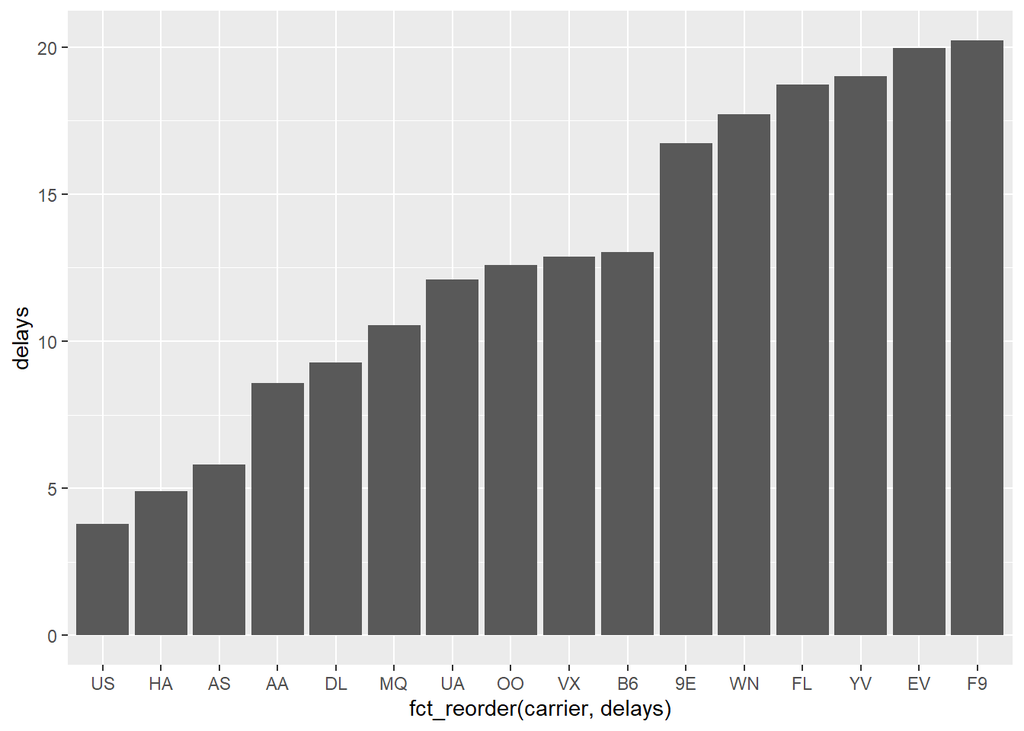

```r
origin_delay <- flights |>
  summarise(
    n = n(),
    delays = mean(dep_delay, na.rm = T), #calculate the average delay
    .by = carrier #group by dest
  ) |>
  arrange(desc(delays))

origin_delay |>
  ggplot()+
  geom_col(aes(x = fct_reorder(carrier, delays), y = delays))
```

However, a lot of the data represent `carrier` and `dest`combinations with few observations:

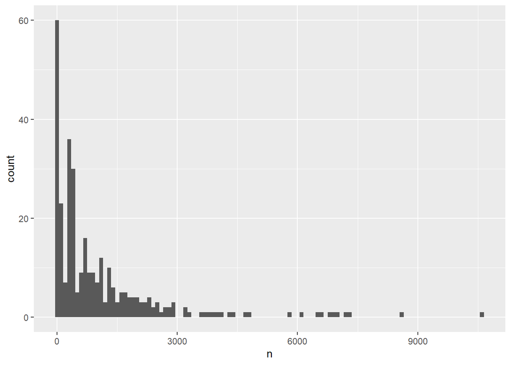

```r
flights |>
  group_by(carrier, dest) |>
  summarize(n = n(), .groups = "drop") |>
  ggplot()+
  geom_histogram(aes(x=n), binwidth = 100)
```

Let’s filter the `carrier` and `dest` flights with less than 100 observations, and then plot the `mean(dep_delay)` for a given `carrier` and `dest`:

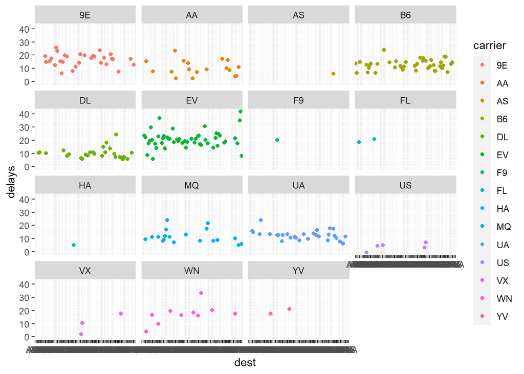

```r
flights |>
  mutate(n = n(),
         .before = 1,
         .by = c(carrier, dest)) |>
  filter(n >= 100) |>
  summarize(n = n(),
            delays = mean(dep_delay, na.rm = T),
            .by = c(carrier,dest)
            ) |>
  ggplot()+
  geom_point(aes(x = dest, y = delays, color = carrier),
             position = position_dodge(.9))+
  facet_wrap( ~ carrier)
```

```r
origin_delay
```

```
## # A tibble: 16 × 3
##    carrier     n delays
##    <chr>   <int>  <dbl>
##  1 F9        685  20.2
##  2 EV      54173  20.0
##  3 YV        601  19.0
##  4 FL       3260  18.7
##  5 WN      12275  17.7
##  6 9E      18460  16.7
##  7 B6      54635  13.0
##  8 VX       5162  12.9
##  9 OO         32  12.6
## 10 UA      58665  12.1
## 11 MQ      26397  10.6
## 12 DL      48110   9.26
## 13 AA      32729   8.59
## 14 AS        714   5.80
## 15 HA        342   4.90
## 16 US      20536   3.78
```

By looking at these two plots, we can see the difficulty in comparing the average delay per carrier in the first graph - some carriers only have one specific flight and become very sensitive to this specific route (e.g. `F9`). At the same time, comparing DL to EV shows that clearly the latter is having a systematic issue with delays across all its destinations.

```r
flights |>
  slice_max(dep_delay, n = 1, by = dest)
```

```
## # A tibble: 105 × 19
##     year month   day dep_time sched_dep_time dep_delay arr_time sched_arr_time
##    <int> <int> <int>    <int>          <int>     <dbl>    <int>          <int>
##  1  2013     4    19      606           1725       761      923           2020
##  2  2013    12     5      756           1700       896     1058           2020
##  3  2013     7    19       30           2050       220      407             42
##  4  2013     7    22     2257            759       898      121           1026
##  5  2013     1    10     1121           1635      1126     1239           1810
##  6  2013     4    19     2346           1700       406      300           2015
##  7  2013     7    27     1456            600       536     1649            712
##  8  2013     4    19      758           1925       753     1049           2225
##  9  2013     7    31     2231           1440       471      118           1749
## 10  2013     4    10     1100           1900       960     1342           2211
## # ℹ 95 more rows
## # ℹ 11 more variables: arr_delay <dbl>, carrier <chr>, flight <int>,
## #   tailnum <chr>, origin <chr>, dest <chr>, air_time <dbl>, distance <dbl>,
## #   hour <dbl>, minute <dbl>, time_hour <dttm>
```

Delays are much worse in the evening

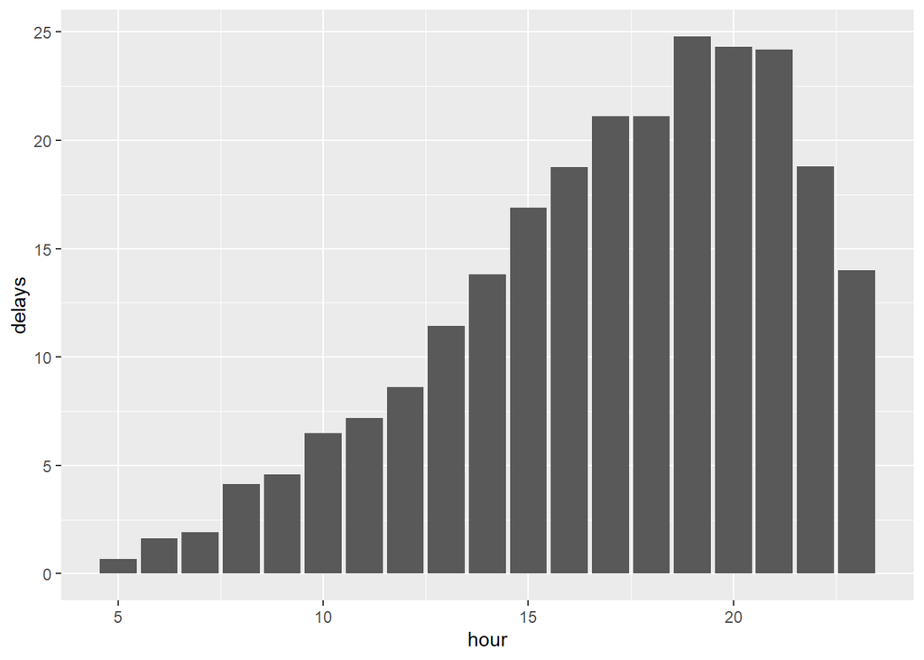

```r
flights |>
  summarise(
    delays = mean(dep_delay,
                  na.rm = TRUE),
    .by = hour
  ) |>
  ggplot()+
  geom_col(aes(x = hour, y = delays))
```

A negative value passed to `n` will make `slice_min()` ignore that many rows of the group - so -1 will make a group of 5 only use 4 rows.

`count()` will calculate the total observations of the group. If you specify `sort = TRUE` it will put the most numerous observation on the top of the output.

1. `group_by(y)` will result in two groups belonging either to a or b.

```r
df <- tibble(
  x = 1:5,
  y = c("a", "b", "a", "a", "b"),
  z = c("K", "K", "L", "L", "K")
)

df |>
  group_by(y)
```

```
## # A tibble: 5 × 3
## # Groups:   y [2]
##       x y     z
##   <int> <chr> <chr>
## 1     1 a     K
## 2     2 b     K
## 3     3 a     L
## 4     4 a     L
## 5     5 b     K
```

2. It will arrange `df` according to `df$y` (a, then b) - the df is not grouped!

```r
df |>
  arrange(y)
```

```
## # A tibble: 5 × 3
##       x y     z
##   <int> <chr> <chr>
## 1     1 a     K
## 2     3 a     L
## 3     4 a     L
## 4     2 b     K
## 5     5 b     K
```

3. It will give give a 2x2 tibble: a `y` column (a or b) and `mean_x` column of x

```r
df |>
  group_by(y) |>
  summarize(mean_x = mean(x))
```

```
## # A tibble: 2 × 2
##   y     mean_x
##   <chr>  <dbl>
## 1 a       2.67
## 2 b       3.5
```

4. Same as above, but a third column `z` and another row as a consequence of `group_by(y, z)`. The message states that the output is now grouped by only `y`, rather than also `z`.

```r
df |>
  group_by(y, z) |>
  summarize(mean_x = mean(x))
```

[output not shown]

```
## # A tibble: 3 × 3
## # Groups:   y [2]
##   y     z     mean_x
##   <chr> <chr>  <dbl>
## 1 a     K        1
## 2 a     L        3.5
## 3 b     K        3.5
```

5. It is different in not maintaining any grouping variable.

```r
df |>
  group_by(y, z) |>
  summarize(mean_x = mean(x), .groups = "drop")
```

```
## # A tibble: 3 × 3
##   y     z     mean_x
##   <chr> <chr>  <dbl>
## 1 a     K        1
## 2 a     L        3.5
## 3 b     K        3.5
```

6. They are different in `mutate` adding a column, and `summarize` producing a new one, consisting of grouping variables and the `mean_x`.

```r
df |>
  group_by(y, z) |>
  summarize(mean_x = mean(x))
```

[output not shown]

```
## # A tibble: 3 × 3
## # Groups:   y [2]
##   y     z     mean_x
##   <chr> <chr>  <dbl>
## 1 a     K        1
## 2 a     L        3.5
## 3 b     K        3.5
```

```r
df |>
  group_by(y, z) |>
  mutate(mean_x = mean(x))
```

```
## # A tibble: 5 × 4
## # Groups:   y, z [3]
##       x y     z     mean_x
##   <int> <chr> <chr>  <dbl>
## 1     1 a     K        1
## 2     2 b     K        3.5
## 3     3 a     L        3.5
## 4     4 a     L        3.5
## 5     5 b     K        3.5
```